# Data Overview

PISA is the Organisation for Economic Co-operation and Development (OECD)'s Programme for International Student Assessment. PISA measures 15-year-olds’ ability to use their reading, mathematics and science knowledge and skills to meet real-life challenges. For this analysis, I focused on resources, mindsets and math outcomes.

*NOTE FROM PISA TECHNICAL GUIDE*

It cannot be emphasised too strongly that the plausible values are not a substitute for test scores for individuals. Plausible values incorporate responses to test items and information about the background of responses; therefore, they cannot be used to compare individuals.

https://www.oecd.org/pisa/sitedocument/PISA-2015-Technical-Report-Chapter-9-Scaling-PISA-Data.pdf

Are the plausible values for our selected countries normally distributed?

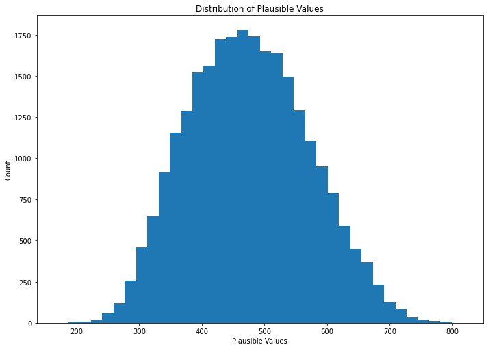

```python
n_bins=np.arange(df_clean["MEAN_PVMATH"].min()-10, df_clean["MEAN_PVMATH"].max()+10, 18)
plt.figure(figsize=[ 11.69, 8.27])
plt.hist(data=df_clean, x="MEAN_PVMATH", bins=n_bins)
plt.title('Distribution of Plausible Values')
plt.xlabel('Plausible Values')
plt.ylabel('Count');
```

The distribution of plausible values from our subset is normal.

How do the country's plausible values, as a mean, compare to one another?

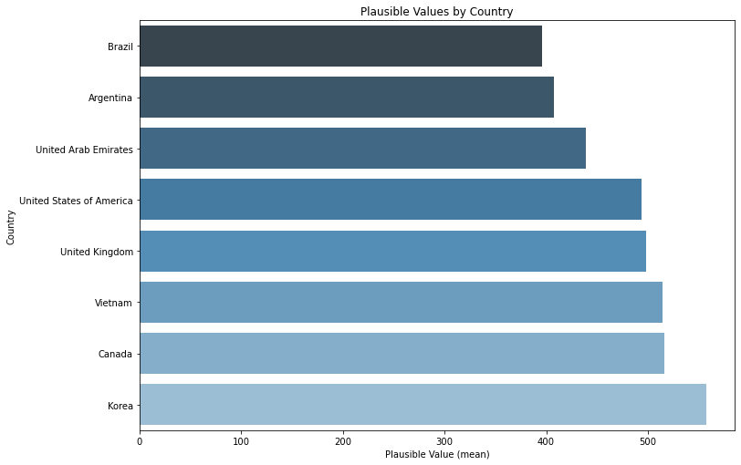

```python
labels = ['Brazil', 'Argentina', 'United Arab Emirates', 'United States of America', 'United Kingdom', 'Vietnam', 'Canada', 'Korea']
plt.figure(figsize=[ 11.69, 8.27])
g=sb.barplot(x="MEAN_PVMATH", y="CNT", data=df_CNT,
                 palette="Blues_d")
g.set_yticklabels(labels)

plt.title('Plausible Values by Country')
plt.xlabel('Plausible Value (mean)')
plt.ylabel('Country');
```

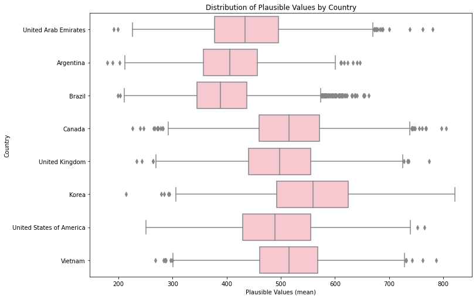

```python
def bibox(A):
    return sb.boxplot(data=df_clean, x='MEAN_PVMATH', y=A, color = "pink");

plt.figure(figsize=[ 11.69, 8.27])
bibox('CNT')
plt.title('Distribution of Plausible Values by Country')
plt.xlabel('Plausible Values (mean)')
plt.ylabel('Country');
```

Which measured factors appear to have the most significant impact on plausible values?

Absences appear to have a meaningful impact on PV.

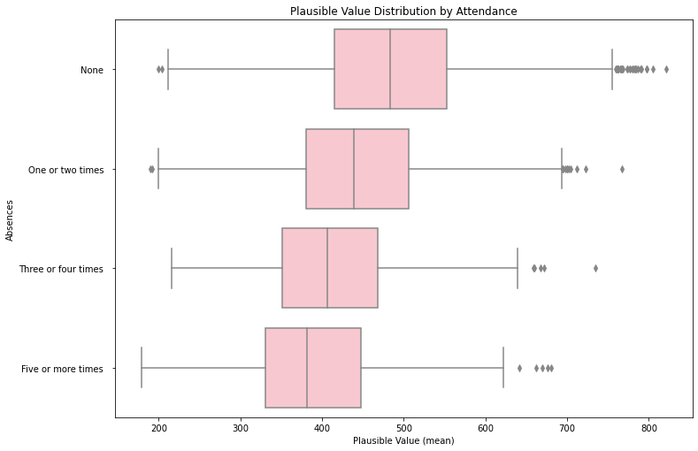

```python
plt.figure(figsize=[ 11.69, 8.27])
bibox('ABSENT')
plt.title('Plausible Value Distribution by Attendance')
plt.xlabel('Plausible Value (mean)')
plt.ylabel('Absences');
```

Desk ownership appears to have a significant impact on PV.

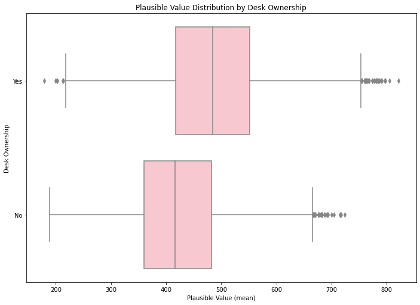

```python
plt.figure(figsize=[ 11.69, 8.27])
bibox('DESK')
plt.title('Plausible Value Distribution by Desk Ownership')
plt.xlabel('Plausible Value (mean)')
plt.ylabel('Desk Ownership');
```

Internet access appears to have a significant impact on PV.

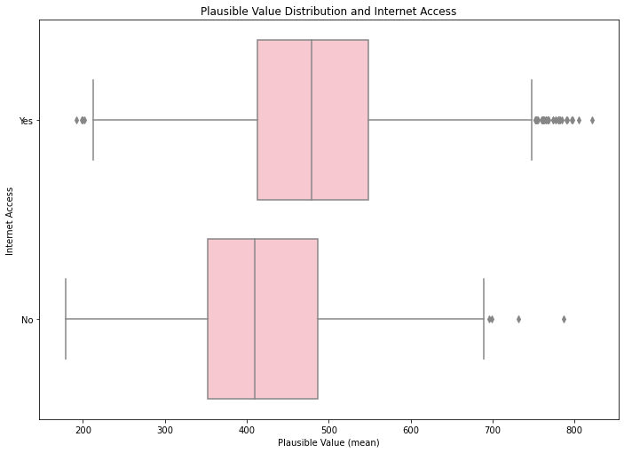

```python
plt.figure(figsize=[ 11.69, 8.27])
bibox('INTERNET')
plt.title('Plausible Value Distribution and Internet Access')
plt.xlabel('Plausible Value (mean)')
plt.ylabel('Internet Access');
```

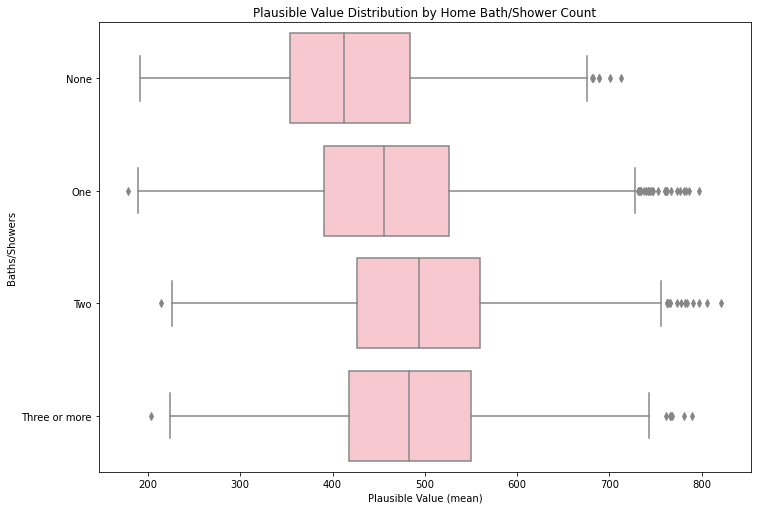

```python
plt.figure(figsize=[ 11.69, 8.27])
bibox('BATHROOM')
plt.title('Plausible Value Distribution by Home Bath/Shower Count')
plt.xlabel('Plausible Value (mean)')
plt.ylabel('Baths/Showers');
```

Books appear to have a meaningful impact on PV.

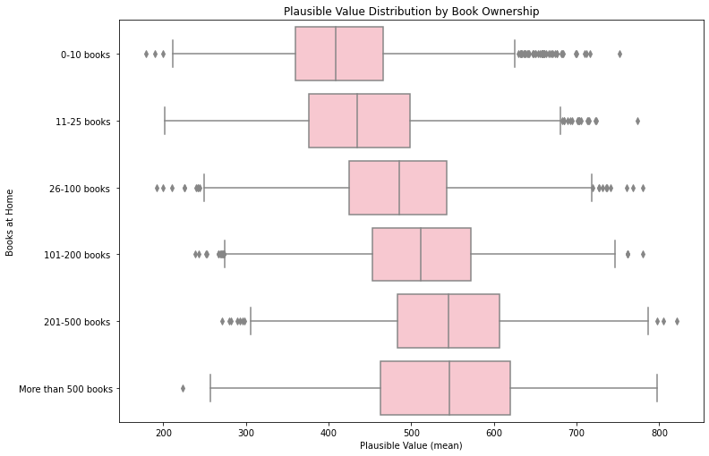

```python
plt.figure(figsize=[ 11.69, 8.27])
bibox("BOOKS")
plt.title('Plausible Value Distribution by Book Ownership')
plt.xlabel('Plausible Value (mean)')
plt.ylabel('Books at Home');
```

Perception of parent belief in the importance of math appears relevant.

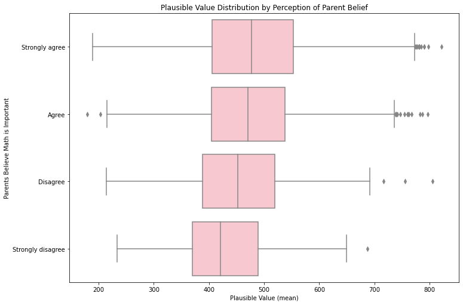

```python
plt.figure(figsize=[ 11.69, 8.27])
bibox('PARENTS_MATH_IMPORTANT')
plt.title('Plausible Value Distribution by Perception of Parent Belief')
plt.xlabel('Plausible Value (mean)')
plt.ylabel('Parents Believe Math is Important');
```

Math anxiety appears relevant to PV.

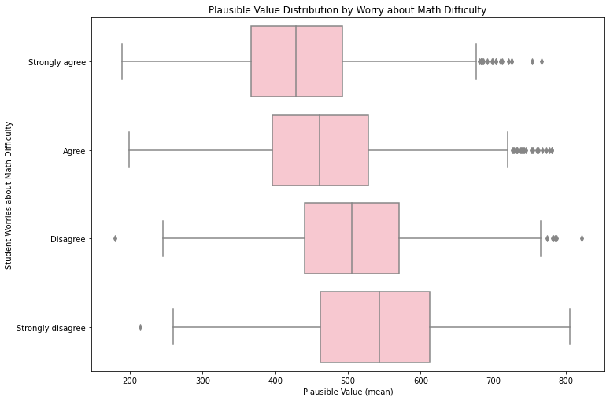

```python
plt.figure(figsize=[ 11.69, 8.27])
bibox('WORRY_MATH_DIFF')
plt.title('Plausible Value Distribution by Worry about Math Difficulty')
plt.xlabel('Plausible Value (mean)')
plt.ylabel('Student Worries about Math Difficulty');
```

Best effort being important appears to be a belief relevant to PV.

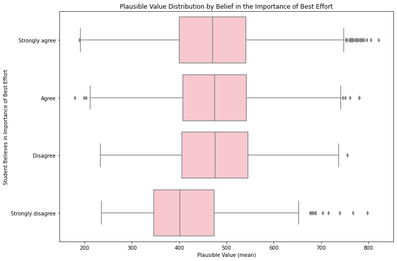

```python
plt.figure(figsize=[ 11.69, 8.27])
bibox('BEST_EFFORT_IMPORTANT')
plt.title('Plausible Value Distribution by Belief in the Importance of Best Effort')
plt.xlabel('Plausible Value (mean)')
plt.ylabel('Student Believes in Importance of Best Effort');
```

Effort being significant to success being important appears to be a belief relevant to PV.

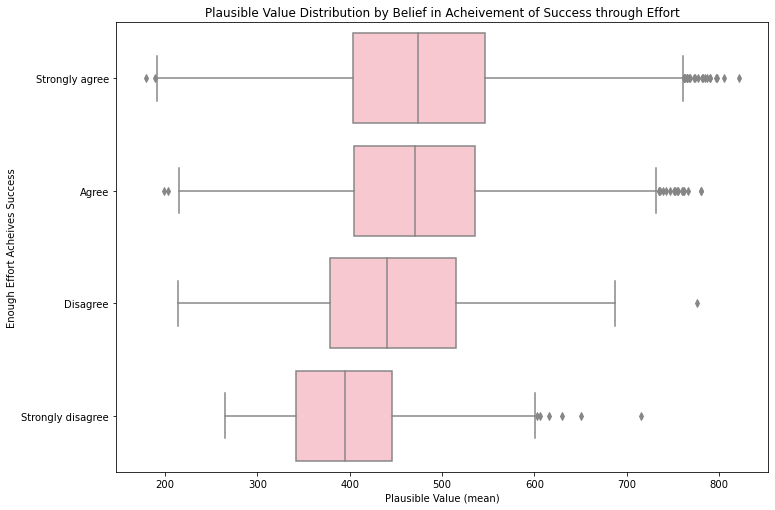

```python
plt.figure(figsize=[ 11.69, 8.27])
bibox('EFFORT=SUCCESS')
plt.title('Plausible Value Distribution by Belief in Acheivement of Success through Effort')
plt.xlabel('Plausible Value (mean)')
plt.ylabel('Enough Effort Acheives Success');
```

Perseverence appears to have significant impact on PV.

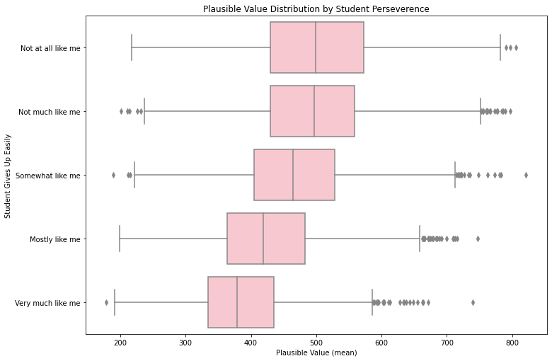

```python
plt.figure(figsize=[ 11.69, 8.27])
bibox('GIVE_UP_EASILY')
plt.title('Plausible Value Distribution by Student Perseverence')
plt.xlabel('Plausible Value (mean)')
plt.ylabel('Student Gives Up Easily');
```

When we compare these factors that appear meaningful by country, what key insights are revealed?

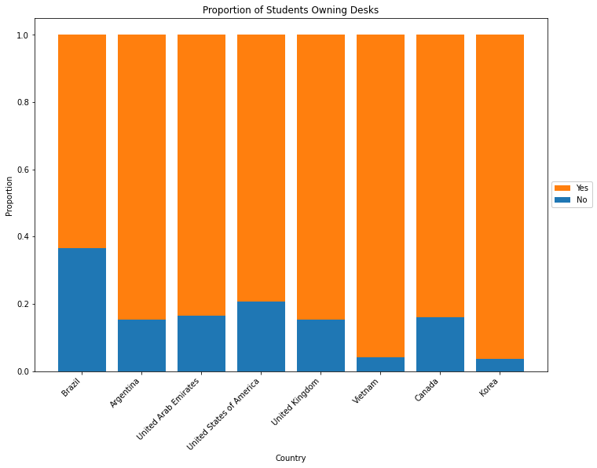

```python
plt.figure(figsize=[ 11.69, 8.27])
propbar("DESK", cat_type7)
plt.title('Proportion of Students Owning Desks')
plt.xlabel('Country')
plt.ylabel('Proportion');
```

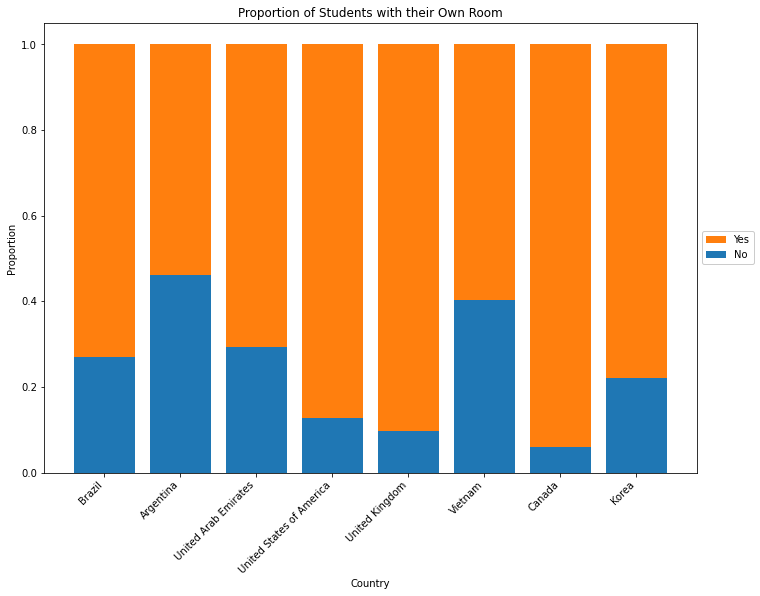

```python
plt.figure(figsize=[ 11.69, 8.27])
propbar("OWN_ROOM", cat_type7)
plt.title('Proportion of Students with their Own Room')
plt.xlabel('Country')
plt.ylabel('Proportion');
```

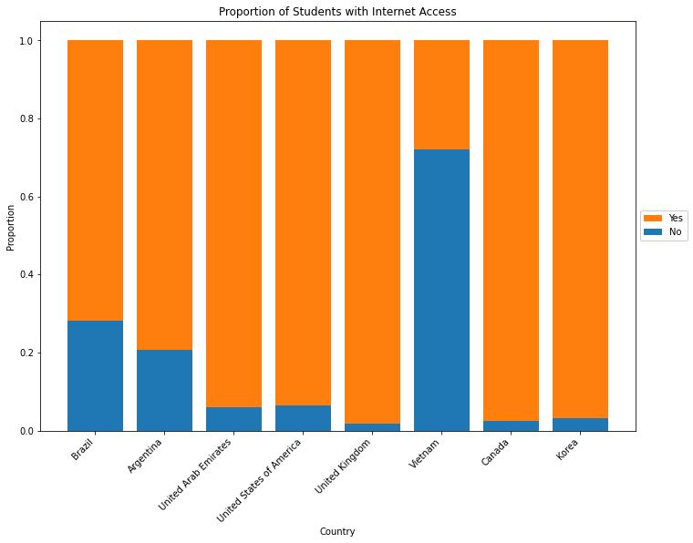

```python
plt.figure(figsize=[ 11.69, 8.27])
propbar("INTERNET", cat_type7)
plt.title('Proportion of Students with Internet Access')
plt.xlabel('Country')
plt.ylabel('Proportion');
```

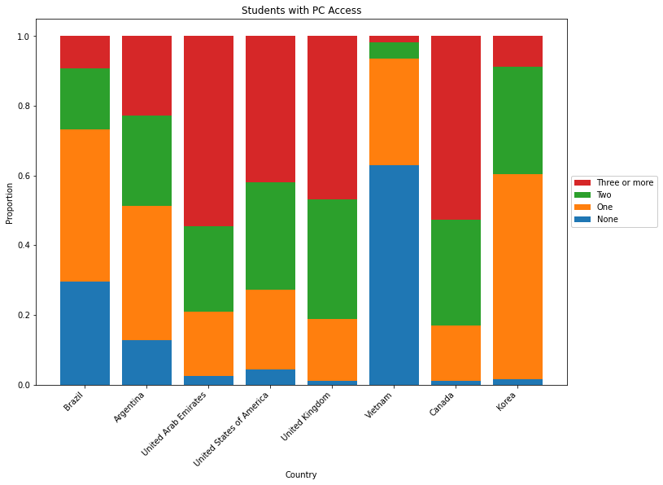

```python
plt.figure(figsize=[ 11.69, 8.27])
propbar("PC", cat_type2)
plt.title('Students with PC Access')
plt.xlabel('Country')
plt.ylabel('Proportion');
```

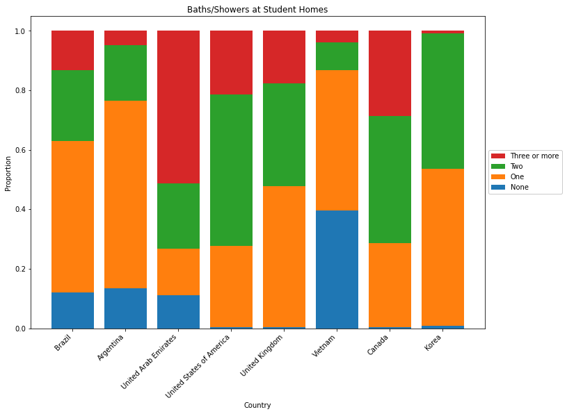

```python
plt.figure(figsize=[ 11.69, 8.27])
propbar('BATHROOM', cat_type2)
plt.title('Baths/Showers at Student Homes')
plt.xlabel('Country')
plt.ylabel('Proportion');
```

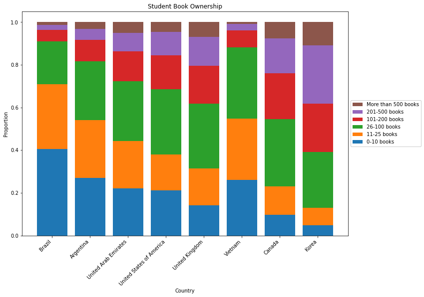

```python
plt.figure(figsize=[ 11.69, 8.27])
propbar("BOOKS", cat_type4)
plt.title('Student Book Ownership')
plt.xlabel('Country')
plt.ylabel('Proportion');
```

Brazil and Vietnam stand out as similarly under-resourced. Why is the distribution of their plausible values so different?

Once we focus on the lesser resourced nations in our subset: Brazil and Vietnam, what trends do we notice?

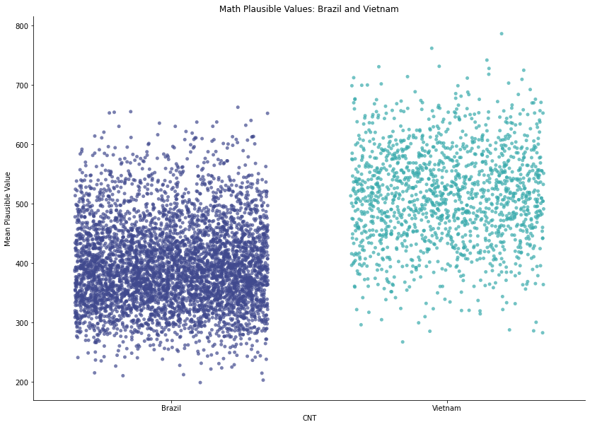

```python
#create dataframe
df1_BRVT = df1[df1['CNT'].isin(['Brazil', 'Vietnam'])]
#visualize score distribution
p=sb.catplot(x='CNT', y="MEAN_PVMATH", palette="mako", data=df1_BRVT, jitter=0.35, alpha=0.7, height=8.27, aspect=11.7/8.27)
p.set(title='Math Plausible Values: Brazil and Vietnam')
p.set(ylabel="Mean Plausible Value");
```

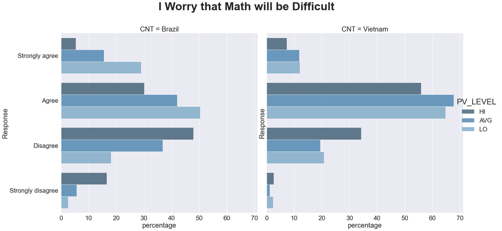

```python
multipropplot_BRVT("WORRY_MATH_DIFF", cat_type3, "I Worry that Math will be Difficult"); #scores by worry that math will be difficult
```

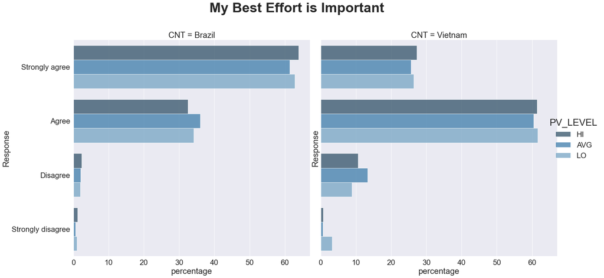

```python
multipropplot_BRVT("BEST_EFFORT_IMPORTANT", cat_type3, "My Best Effort is Important"); #scores by belief in importance of best effort
```

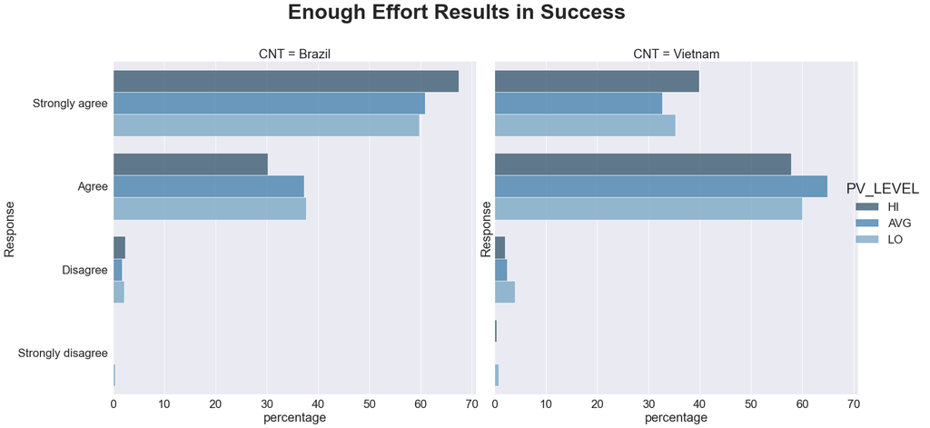

```python
multipropplot_BRVT("EFFORT=SUCCESS", cat_type3, "Enough Effort Results in Success"); #scores by belief that success can be achieved with enough effort
```

Almost none of Brazilian students strongly disagree that enough effort results in success.

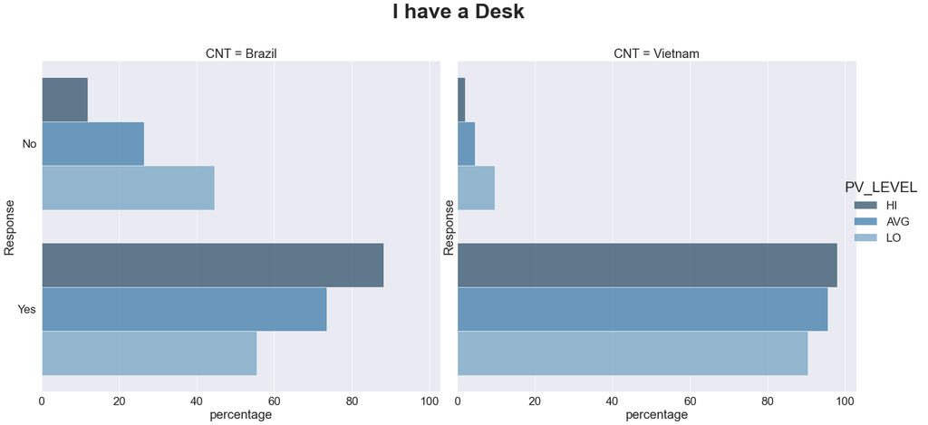

```python
multipropplot_BRVT("DESK", cat_type7, "I have a Desk");
```

While a greater proporiton of Vietnamese students have desks, it appears to have less impact on their scores.

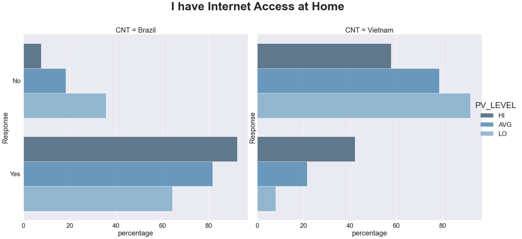

```python
multipropplot_BRVT("INTERNET", cat_type7, "I have Internet Access at Home");
```

Internet is more common among HI scoring students, but most Vietnamese students do not have access.

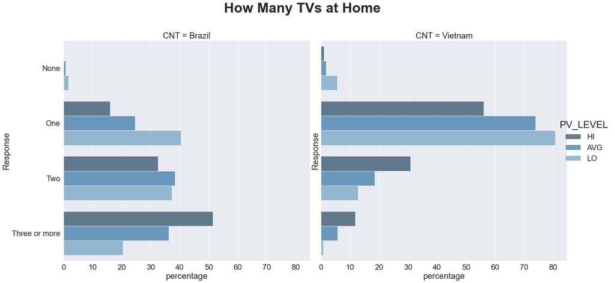

```python
multipropplot_BRVT("TV", cat_type2, "How Many TVs at Home");
```

TV ownership appears a little more significantly correlated with HI scores for the Brazilian subset. More than half HI scoring have 3+ TVs.

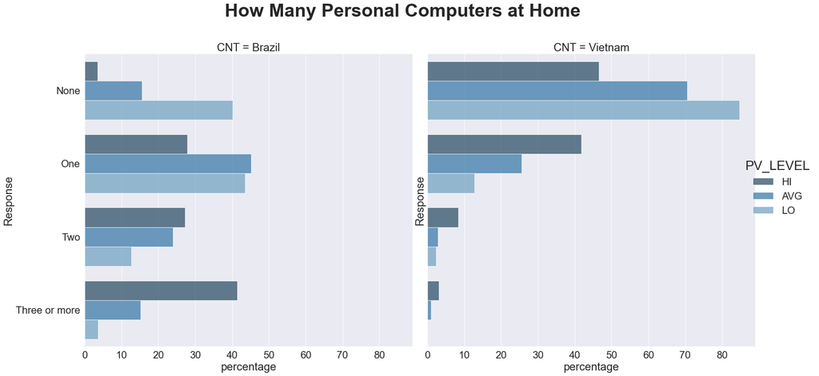

```python
multipropplot_BRVT("PC", cat_type2, "How Many Personal Computers at Home");
```

This is different from the dataset as a whole--LO scoring is significantly more skewed to fewer PCs for Brazilian students. Having several PCs is unlikely for any Vietnamese student, though a greater proportion of LO scoring students have none.

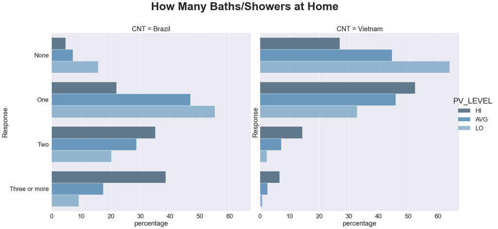

```python
multipropplot_BRVT("BATHROOM", cat_type2, "How Many Baths/Showers at Home");
```

Also different--HI scoring is skewed more toward more baths/showers for Brazilian students. However, not true for Vietnamese students; HI scoring were most likely to have just one bath/shower.

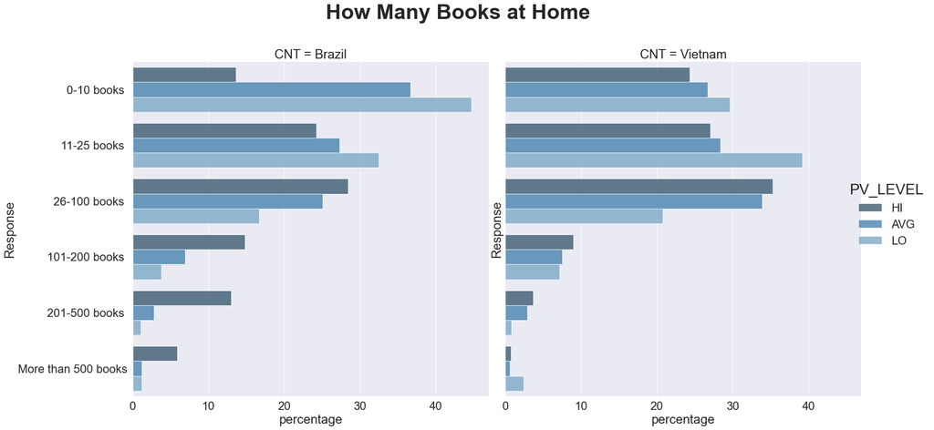

```python
multipropplot_BRVT("BOOKS", cat_type4, "How Many Books at Home");
```

Both Vietnamese and Brazilian students have fewer books in general, with 26-100 books being the threshold for the highest proportion of HI scoring students. It seems much less significant for Vietnamese students, where the proportion of LO scoring students even outpaces other groups for more than 500 books.

# Conclusion

Viewing the dataset as a whole, and within nations, there were key insights into the correlations between mindset, access, and math PV outcomes. My findings revealed desks, PCs, internet access, and books in the home all positively impact the distritution of PV. As do beliefs about the importance of effort, its relationship to success, perseverance, and perception of parental belief in math importance.

While we could see correlations within the nations, there were not any clear patterns uncovered to explain why Vietnamese students' PV was so much greater than Brazilian students' PV. Perhaps there is a compounding generational factor that isn't sufficiently measured by the current PISA methodology.